# pandas

### Python Pandas - Indexing and Selecting Data

- Pandas supports three types of Multi-axes indexing; the three types are mentioned in the following table
- .loc() - **Label based**
- .iloc() - **Integer based**
- .ix() - **Both Label and Integer based**

### .loc()

Pandas provide various methods to have purely label based indexing. When slicing, the start bound is also included. Integers are valid labels, but they refer to the label and not the position

```python
#import the pandas library and aliasing as pd
import pandas as pd
import numpy as np
import matplotlib.pyplot as plt

df = pd.DataFrame(np.random.randn(8, 4),
index = ['a','b','c','d','e','f','g','h'], columns = ['A', 'B', 'C', 'D'])

#select all rows for a specific column
df.loc[:,'A']
```

```
a    0.174103
b    0.359755
c    1.694705
d    0.418925
e    0.663381
f   -0.269614
g    0.307658
h   -0.701248
Name: A, dtype: float64
```

```python
# Select all rows for multiple columns, say list[]
print(df.loc[:,['A','C']])
```

```
          A         C
a  0.174103  1.236815
b  0.359755 -0.446482
c  1.694705 -0.323514
d  0.418925  0.086709
e  0.663381  0.051733
f -0.269614 -1.436561
g  0.307658  0.906576
h -0.701248  2.645151
```

```python
# Select few rows for multiple columns, say list[]
print(df.loc[['a','b','f','h'],['A','C']])
```

[output not shown]

```python
# Select range of rows for all columns
print (df.loc['a':'h'])
```

[output not shown]

### .iloc()

Pandas provide various methods in order to get purely integer based indexing. Like python and numpy, these are 0-based indexing.

The various access methods are as follows −

> An Integer  
> A list of integers  
> A range of values

```python
# Integer slicing
print (df.iloc[:4])
print (df.iloc[1:5, 2:4])
```

```
          A         B         C         D
a  0.174103 -1.551744  1.236815 -0.791889
b  0.359755  2.374877 -0.446482 -0.499792
c  1.694705  1.731534 -0.323514 -0.315944
d  0.418925  1.267087  0.086709 -0.495201
          C         D
b -0.446482 -0.499792
c -0.323514 -0.315944
d  0.086709 -0.495201
e  0.051733 -0.843929
```

```python
df
```

[output not shown]

[figure not shown]

```python
#Generate a normal distribution
u=5
sigma=2
vals=u + sigma*(np.random.randn(1000))
print(vals)
print(vals.shape)
```

[output not shown]

[output cut: 113 more lines]

[output not shown]

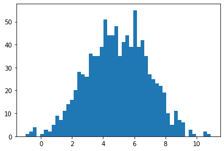

```python
plt.hist(vals,50)
plt.show()
```

```python
vals=np.round(vals)
```

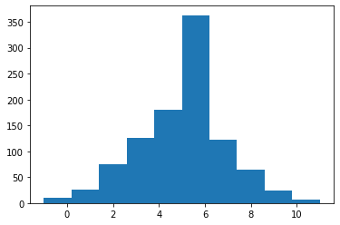

```python
plt.hist(vals)
```

```python
np.unique(vals,return_counts=True)
```

```
(array([-1.,  0.,  1.,  2.,  3.,  4.,  5.,  6.,  7.,  8.,  9., 10., 11.]),
 array([  3,   8,  26,  75, 126, 180, 181, 182, 122,  65,  25,   4,   3]))
```

#### The data is termed mutivariate when more than one variable is being observed. For this question, each observation has two variables (the data is 2-dimensional.) For the multivariate datapoint x, having d dimensions, the Gaussian density function is

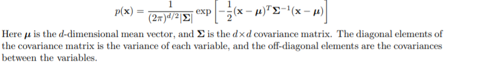

When working with multiple variables, the covariance matrix provides a succinct way to summarize the covariances of all pairs of variables. In particular, the covariance matrix, which we usually denote as Σ, is the n × n matrix whose (i, j)th entry is Cov[Xi, Xj].

Also the covariance matrix is symmetric. The diagonal entries of the covariance matrix are the variances and the other entries are the covariances. For this reason, the covariance matrix is sometimes called the *variance-covariance matrix*

```
[[-2.10032144 -1.76842609]
 [-1.22954846 -1.25831107]
 [-0.56121196 -0.52822081]
 [-1.3094943  -0.67712334]
 [ 1.05122503 -1.22466169]]
(500, 2)
```

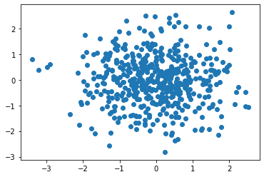

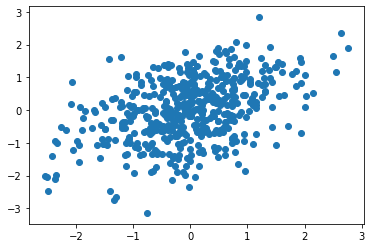

```python
#Bi-Variate(say height and weight)
mean1=np.array([0,0])
cov1=np.array([[1,0],[0,1]])#say color and weight

# clearly the distribution is concentrated around (0,0)
# σxx= σyy=1, σxy= σyx=0[uncorelated](say color and weight of monkey)

mean2=np.array([0,0])
cov2=np.array([[1,0.5],[0.5,1]])# say height and weight as positively correlated

dist1=np.random.multivariate_normal(mean1,cov1,500)
dist2=np.random.multivariate_normal(mean2,cov2,500)

print(dist1[0:5])
print(dist1.shape)
plt.scatter(dist1[:,0],dist1[:,1])
plt.show()
plt.scatter(dist2[:,0],dist2[:,1])
plt.show()
```

**Therefore, the covariance matrix is always a symmetric matrix with the variances on its diagonal and the covariances off-diagonal. Two-dimensional normally distributed data is explained completely by its mean and its 2x2 covariance matrix. Similarly, a 3x3 covariance matrix is used to capture the spread of three-dimensional data, and a NxN covariance matrix captures the spread of N-dimensional data**

```
[[-1.47077959 -0.60558721]
 [-1.29081667 -1.85449433]
 [-0.55849341  0.14103786]
 [ 0.90003608  0.15132687]
 [ 0.56645302 -0.51673753]]
(500, 2)
```

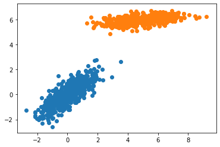

```python
#Bi-Variate(say height and weight)
mean1=np.array([0,0])
cov1=np.array([[1,0.8],[0.8,1]])#say color and weight

# clearly the distribution is concentrated around (0,0)
# σxx= σyy=1, σxy= σyx=0[uncorelated](say color and weight of monkey)

mean2=np.array([5,6])
cov2=np.array([[1.8,0.2],[0.2,0.1]])# say height and weight as positively correlated

dist1=np.random.multivariate_normal(mean1,cov1,500)
dist2=np.random.multivariate_normal(mean2,cov2,500)

print(dist1[0:5])
print(dist1.shape)
plt.scatter(dist1[:,0],dist1[:,1])
plt.scatter(dist2[:,0],dist2[:,1])
plt.show()
```

[figure not shown]

```python
import scipy.stats as st
import numpy as np
import math
import matplotlib.pyplot as plt
norm=st.norm.pdf
cdf=st.norm.cdf
```

```python
norm(0)
```

```
0.3989422804014327
```

```python
cdf(0)
```

```
0.5
```

```python
cdf(1.1006)
```

```
0.864464607226755
```